# Solution to Exercise 1

Gerko Vink

Markup Languages and Reproducible Programming in Statistics

This is an exercise in Monte Carlo simulation, that also details a reproducible workflow. But we’ll consider more about reproducibility in the next meeting.

We start by fixing the random seed. Otherwise this whole exercise is redundant.

```r
set.seed(1234)
```

Then, we draw 100 samples from a standard normal distribution, i.e. a distribution with $\mu=0$ and $\sigma^2=1$, such that for any drawn sample $X$ we could write $X \sim \mathcal{N}(0, 1)$. No specification about the size of the samples is explicitly requested, so for computational reasons a mere 5000 cases would suffice to obtain a detailed approximation.

```r
library(plyr)
samples <- rlply(100, rnorm(5000, mean = 0, sd = 1))
```

We use the `plyr::rlply()` function to draw the 100 samples and return the resulting output as a list. Further, we extract the following sources of information for each sample:

- the sample mean $\bar{x}$.
- the absolute bias: i.e. $|\bar{x} - \mu|$, which would be $\bar{x}$ in this case.
- the standard error of the mean: $SE = \sigma/\sqrt{n}$, where $\sigma$ is the known population standard deviation and $n$ is the number of observations in the sample.
- the upper- and lower bounds of the 95% confidence interval about the sample mean:

```r
info <- function(x){
  M <- mean(x)
  DF <- length(x) - 1
  SE <- 1 / sqrt(length(x))
  INT <- qt(.975, DF) * SE
  return(c(M, M - 0, SE, M - INT, M + INT))
}
format <- c("Mean" = 0, "Bias" = 0, "Std.Err" = 0, "Lower" = 0, "Upper" = 0)
```

We can then proceed by creating a piped process. The following code is written with the pipe functionality from package [`magrittr`](http://magrittr.tidyverse.org) - FYI: [`dplyr`](http://dplyr.tidyverse.org) adopted `magrittr`’s default pipe, so `dplyr` would also work here.

```r
library("magrittr")
results <- samples %>%
  vapply(., info, format) %>%
  t()
```

Because object `samples` is a list, we can execute funtion `vapply()` to obtain a numerical object with the results of function `info()`. `vapply()` allows you to return output to a pre-defined format. Function $t()$ is here used to obtain the transpose of `vapply()`’s return - the resulting object has all information in the columns.

To create an indicator for the inclusion of the population value $\mu=0$ in the confidence interval, we can add the following coverage column `cov` to the data:

```r
results <- results %>%
  as.data.frame() %>%
  mutate(Covered = Lower < 0 & 0 < Upper)
```

Converting the numerical object to an object of class `data.frame` allows for a more convenient calling of elements. Now we can simply take the column means over dataframe `results` to obtain the average of the estimates returned by `info()`.

```r
colMeans(results)
```

```
##         Mean         Bias      Std.Err        Lower        Upper      Covered
##  0.001341244  0.001341244  0.014142136 -0.026383545  0.029066033  0.950000000
```

We can see that 95 out of the 100 samples cover the population value.

To identify the samples for which the population value is not covered, we can use column `cov` as it is already a logical evaluation.

```r
table <- results[!results$Covered, ]
```

To present this info as a table, package `kableExtra` is a wonderful extension to use with both `rmarkdown` and $\LaTeX$.

```r
library(knitr)
library(kableExtra)
kable(table)
```

|  | Mean | Bias | Std.Err | Lower | Upper | Covered |
| --- | --- | --- | --- | --- | --- | --- |
| 20 | 0.0389823 | 0.0389823 | 0.0141421 | 0.0112575 | 0.0667071 | FALSE |
| 21 | 0.0311591 | 0.0311591 | 0.0141421 | 0.0034343 | 0.0588839 | FALSE |
| 41 | 0.0387800 | 0.0387800 | 0.0141421 | 0.0110552 | 0.0665048 | FALSE |
| 43 | 0.0305673 | 0.0305673 | 0.0141421 | 0.0028425 | 0.0582921 | FALSE |
| 98 | 0.0283847 | 0.0283847 | 0.0141421 | 0.0006599 | 0.0561094 | FALSE |

```r
kable(table, "html") %>%
  kable_styling(bootstrap_options = c("striped", "hover", "condensed"),
                full_width = F,
                position = "float_right")
```

|  | Mean | Bias | Std.Err | Lower | Upper | Covered |
| --- | --- | --- | --- | --- | --- | --- |
| 20 | 0.0389823 | 0.0389823 | 0.0141421 | 0.0112575 | 0.0667071 | FALSE |
| 21 | 0.0311591 | 0.0311591 | 0.0141421 | 0.0034343 | 0.0588839 | FALSE |
| 41 | 0.0387800 | 0.0387800 | 0.0141421 | 0.0110552 | 0.0665048 | FALSE |
| 43 | 0.0305673 | 0.0305673 | 0.0141421 | 0.0028425 | 0.0582921 | FALSE |
| 98 | 0.0283847 | 0.0283847 | 0.0141421 | 0.0006599 | 0.0561094 | FALSE |

For an even more flexible presentation of tabulated results, the graphical parameters for `kable()` can be changed. For example, the following code renders a table that does not span the width of the page, is in a right-aligned floating container and has some visually pleasing aesthetics, like striping, hovering (mouse pointer) and is somewhat condensed.

However, you need to pay attention to the final result. Justified floats have a tendency to mess up the ‘natural’ flow of the text, unless the body of text is sufficiently large. For example, this whole paragraph serves that purpose: to create a suffiently large body of text.

To create a graph that would serve the purpose of the exercise, one could think about the following graph:

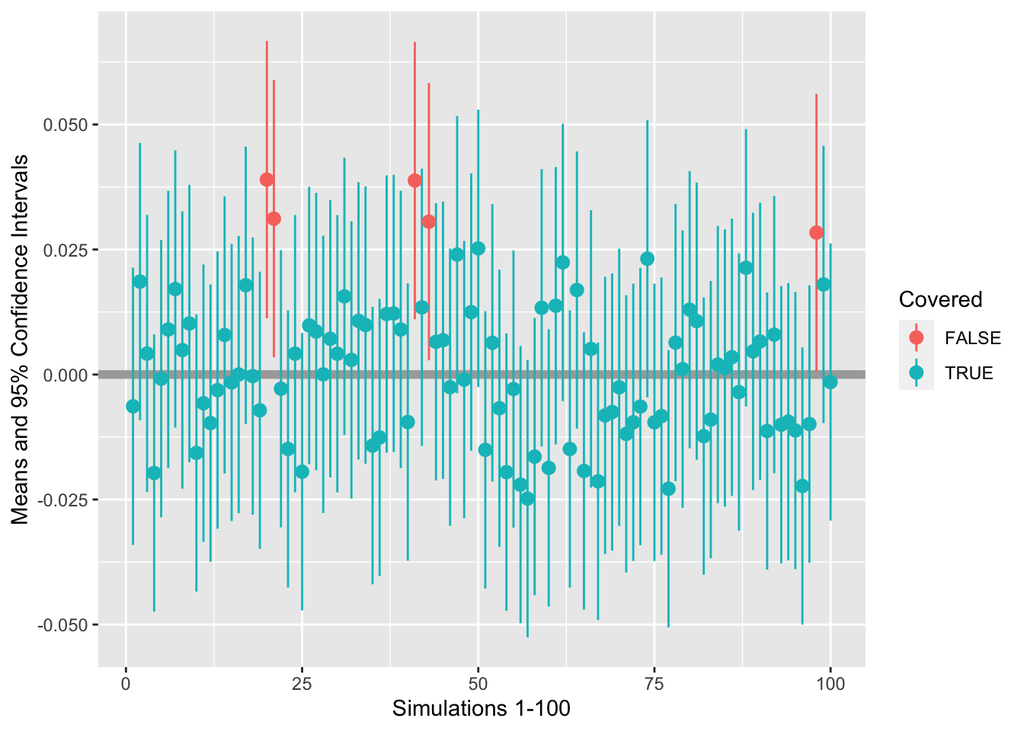

```r
library(ggplot2)
limits <- aes(ymax = results$Upper, ymin = results$Lower)
ggplot(results, aes(y=Mean, x=1:100, colour = Covered)) +
  geom_hline(aes(yintercept = 0), color = "dark grey", size = 2) +
  geom_pointrange(limits) +
  xlab("Simulations 1-100") +
  ylab("Means and 95% Confidence Intervals")
```

End of solution.